# Lab 4

## Part 1

```r
#Def
defClean <- defense

defClean$Name <- factor(defClean$Name)
defClean$Opponent_Opponent <- factor(defClean$Opponent_Opponent)

defClean$Tackles_Solo <- as.numeric(defClean$Tackles_Solo)
defClean$Tackles_ASST <- as.numeric(defClean$Tackles_ASST)
defClean$Tackles_TFL <- as.numeric(defClean$Tackles_TFL)
defClean$Tackles_Sack <- as.numeric(defClean$Tackles_Sack)

defClean$Turnover_FF <- as.numeric(defClean$Turnover_FF)
defClean$Turnover_FR <- as.numeric(defClean$Turnover_FR)
defClean$Turnover_INT <- as.numeric(defClean$Turnover_INT)
defClean$Pass_QBH <- as.numeric(defClean$Pass_QBH)
defClean$Pass_PB <- as.numeric(defClean$Pass_PB)

str(defClean)
```

```
## tibble [502 x 11] (S3: tbl_df/tbl/data.frame)
##  $ Name             : Factor w/ 43 levels "Akers, Landen",..: 40 40 40 40 40 40 40 40 40 40 ...
##  $ Opponent_Opponent: Factor w/ 13 levels "Baylor","Iowa",..: 12 2 11 1 8 13 10 7 6 9 ...
##  $ Tackles_Solo     : num [1:502] 4 4 3 4 3 1 7 3 6 5 ...
##  $ Tackles_ASST     : num [1:502] 4 7 5 2 2 1 1 2 1 5 ...
##  $ Tackles_TFL      : num [1:502] 0 0 0 0 1 0 0 0 1 1 ...
##  $ Tackles_Sack     : num [1:502] 0 0 0 0 0 0 0 0 0 1 ...
##  $ Turnover_FF      : num [1:502] 0 0 0 0 0 0 0 0 0 0 ...
##  $ Turnover_FR      : num [1:502] 0 0 0 0 0 0 0 0 0 0 ...
##  $ Turnover_INT     : num [1:502] 0 0 1 0 0 0 0 0 1 0 ...
##  $ Pass_QBH         : num [1:502] 1 0 0 0 0 0 0 0 1 0 ...
##  $ Pass_PB          : num [1:502] 1 2 0 0 0 1 0 0 0 0 ...
```

```r
#Off
offClean <- offensive

offClean$Name <- factor(offClean$Name)
offClean$Opponent_Opponent <- factor(offClean$Opponent_Opponent)

offClean$Rushing_ATT <- as.numeric(offClean$Rushing_ATT)
offClean$Rushing_YDS <- as.numeric(offClean$Rushing_YDS)
offClean$Rushing_TD <- as.numeric(offClean$Rushing_TD)
offClean$Receiving_REC <- as.numeric(offClean$Receiving_REC)
offClean$Receiving_YDS <- as.numeric(offClean$Receiving_YDS)
offClean$Receiving_TD <- as.numeric(offClean$Receiving_TD)
offClean$Passing_YDS <- as.numeric(offClean$Passing_YDS)
offClean$Passing_TD <- as.numeric(offClean$Passing_TD)
offClean$Passing_INT <- as.numeric(offClean$Passing_INT)

str(offClean)
```

```
## tibble [195 x 12] (S3: tbl_df/tbl/data.frame)
##  $ Name             : Factor w/ 17 levels "Akers, Landen",..: 1 1 1 1 1 1 1 1 1 1 ...
##  $ Opponent_Opponent: Factor w/ 13 levels "Baylor","Iowa",..: 12 2 11 1 8 13 10 7 6 9 ...
##  $ Rushing_ATT      : num [1:195] 0 0 1 0 0 0 0 0 0 0 ...
##  $ Rushing_YDS      : num [1:195] 0 0 8 0 0 0 0 0 0 0 ...
##  $ Rushing_TD       : num [1:195] 0 0 0 0 0 0 0 0 0 0 ...
##  $ Receiving_REC    : num [1:195] 1 0 0 0 1 0 0 4 0 1 ...
##  $ Receiving_YDS    : num [1:195] 21 0 0 0 32 0 0 39 0 7 ...
##  $ Receiving_TD     : num [1:195] 0 0 0 0 0 0 0 0 0 0 ...
##  $ Passing_CMP-ATT  : chr [1:195] NA NA NA NA ...
##  $ Passing_YDS      : num [1:195] NA NA NA NA NA NA NA NA NA NA ...
##  $ Passing_TD       : num [1:195] NA NA NA NA NA NA NA NA NA NA ...
##  $ Passing_INT      : num [1:195] NA NA NA NA NA NA NA NA NA NA ...
```

```r
#Bio
bioClean <- biography

bioClean$Name <- factor(bioClean$Name)

bioClean$Weight <- as.numeric(bioClean$Weight)
bioClean$Height <- gsub("-", ".", bioClean$Height)
bioClean$Height <- as.numeric(bioClean$Height)

str(bioClean)
```

```
## tibble [105 x 7] (S3: tbl_df/tbl/data.frame)
##  $ Name      : Factor w/ 105 levels "Akers, Landen",..: 1 2 3 4 5 6 7 8 9 10 ...
##  $ Position  : chr [1:105] "Wide Receiver" "Tight End" "Wide Receiver" "Placekicker" ...
##  $ Height    : num [1:105] 6 6.7 6.5 6 6 6.3 6.2 6.2 6 6.6 ...
##  $ Weight    : num [1:105] 188 245 204 195 190 235 255 285 300 215 ...
##  $ Class     : chr [1:105] "Redshirt Senior" "Redshirt Senior" "Redshirt Freshman" "Redshirt Senior" ...
##  $ Hometown  : chr [1:105] "Cedar Rapids, Iowa" "Nixa, Mo." "Seffner, Fla." "Naperville, Ill." ...
##  $ Highschool: chr [1:105] "Washington" "Nixa" "Armwood" "Central" ...
```

## Part 2

#### 1

```r
#1
defClean2 <- defClean
defClean <- pivot_longer(defClean, cols = c(Tackles_Solo, Tackles_ASST, Tackles_TFL, Tackles_Sack, Turnover_INT, Turnover_FR, Turnover_FF, Pass_PB, Pass_QBH), names_to = "stat", values_to = "count" )
str(defClean)
```

```
## tibble [4,518 x 4] (S3: tbl_df/tbl/data.frame)
##  $ Name             : Factor w/ 43 levels "Akers, Landen",..: 40 40 40 40 40 40 40 40 40 40 ...
##  $ Opponent_Opponent: Factor w/ 13 levels "Baylor","Iowa",..: 12 12 12 12 12 12 12 12 12 2 ...
##  $ stat             : chr [1:4518] "Tackles_Solo" "Tackles_ASST" "Tackles_TFL" "Tackles_Sack" ...
##  $ count            : num [1:4518] 4 4 0 0 0 0 0 1 1 4 ...
```

#### 2

**Answer**

- The most rare defensive skills are Turnover_INT, Turnover_FR, and Turnover_FF due to them having the lowest occurrences for any player.

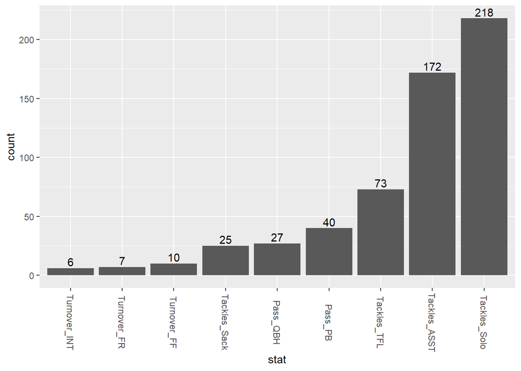

```r
Tackles_Solo <- count_if(gt(0), defClean2$Tackles_Solo)
Tackles_ASST <- count_if(gt(0), defClean2$Tackles_ASST)
Tackles_TFL <- count_if(gt(0), defClean2$Tackles_TFL)
Tackles_Sack <- count_if(gt(0), defClean2$Tackles_Sack)
Turnover_FF <- count_if(gt(0), defClean2$Turnover_FF)
Turnover_FR <- count_if(gt(0), defClean2$Turnover_FR)
Turnover_INT <- count_if(gt(0), defClean2$Turnover_INT)
Pass_QBH <- count_if(gt(0), defClean2$Pass_QBH)
Pass_PB <- count_if(gt(0), defClean2$Pass_PB)
defCount <- data.frame(Tackles_Solo, Tackles_ASST, Tackles_TFL, Tackles_Sack, Turnover_FF, Turnover_FR, Turnover_INT, Pass_QBH, Pass_PB)
defCount <- pivot_longer(defCount, cols = c(Tackles_Solo, Tackles_ASST, Tackles_TFL, Tackles_Sack, Turnover_FF, Turnover_FR, Turnover_INT, Pass_QBH, Pass_PB), names_to = "stat", values_to = "count")
defCount <- defCount %>% arrange(count) %>% mutate(stat=factor(stat, levels=stat))
ggplot(defCount, aes(x = stat, y = count)) + geom_bar(position = 'dodge', stat='identity') + geom_text(aes(label=count), position=position_dodge(width=0.9), vjust=-0.25) + theme(axis.text.x=element_text(angle = -90, vjust = 0.5))
```

#### 3

**Answer**

- The defense against Notre Dame was better because there is a higher count of solo tackles more often

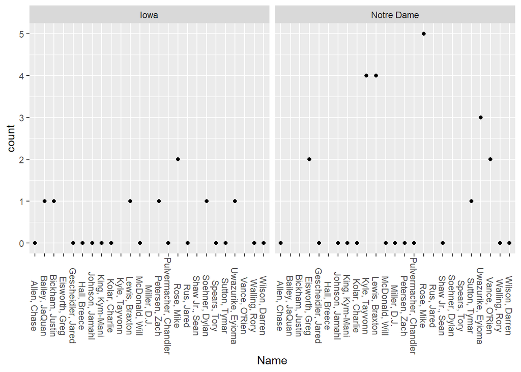

```r
soloTI <- defClean[defClean$Opponent_Opponent == c("Iowa", "Notre Dame") & defClean$stat == "Tackles_Solo",]
ggplot(soloTI, aes(x = Name, y = count)) + geom_point() + theme(axis.text.x=element_text(angle = -90, vjust = 0.5)) + facet_wrap(~Opponent_Opponent)
```

#### 4

```r
bioClean <- separate(bioClean, col = Hometown, into=c("City", "State"), sep = ",")
select(bioClean, City, State) %>% head
```

```
## # A tibble: 6 x 2
##   City          State
##   <chr>         <chr>
## 1 Cedar Rapids  " Iowa"
## 2 Nixa          " Mo."
## 3 Seffner       " Fla."
## 4 Naperville    " Ill."
## 5 Grand Prairie " Texas"
## 6 Clarksdale    " Miss."
```

#### 5

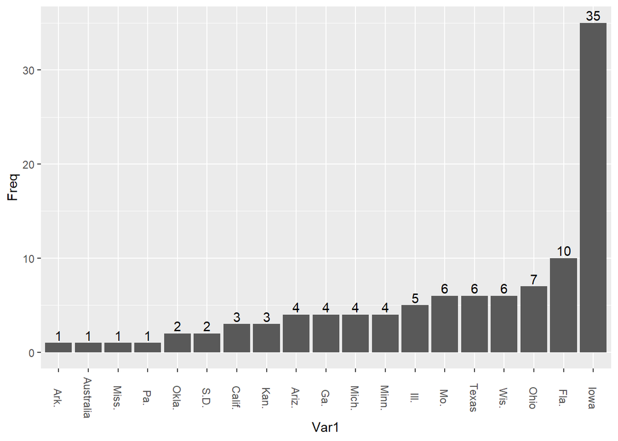

```r
numPlayersFromState <- data.frame(table(bioClean$State))
numPlayersFromState <- numPlayersFromState %>% arrange(Freq) %>% mutate(Var1=factor(Var1, levels=Var1))
ggplot(numPlayersFromState, aes(x = Var1, y = Freq)) + geom_bar(position = 'dodge', stat='identity') + geom_text(aes(label=Freq), position=position_dodge(width=0.9), vjust=-0.25) + theme(axis.text.x=element_text(angle = -90, vjust = 0.5))
```

## Part 3

#### 1

**Answer**

- The defense team is from Ark., Calif., Fla., Ga., Iowa, Kan., Mich., Mo,. Ohio., Okla., Texas, Wis.
- The offense team is from Ariz., Ark., Fla., Ga., Ill., Iowa, Kan., Mo., Ohio, Okla., Texas

```r
defCleanStates <- left_join(defClean, bioClean, by = "Name")
defCleanStates <- select(defCleanStates, Name, State)
defCleanStates <- unique(defCleanStates[!is.na(defCleanStates$State),])
defCleanStates <- data.frame(table(defCleanStates$State))
summary(defCleanStates$Var1)
```

```
##    Ark.  Calif.    Fla.     Ga.    Iowa    Kan.   Mich.     Mo.    Ohio   Okla.
##       1       1       1       1       1       1       1       1       1       1
##   Texas    Wis.
##       1       1
```

```r
offCleanStates <- left_join(offClean, bioClean, by = "Name")
offCleanStates <- select(offCleanStates, Name, State)
offCleanStates <- unique(offCleanStates[!is.na(offCleanStates$State),])
offCleanStates <- data.frame(table(offCleanStates$State))
summary(offCleanStates$Var1)
```

```
##  Ariz.   Ark.   Fla.    Ga.   Ill.   Iowa   Kan.    Mo.   Ohio  Okla.  Texas
##      1      1      1      1      1      1      1      1      1      1      1
```

#### 2

**Answer**

- You can see in the games where Brock Purdy performs better (more touchdown passes), the rest of the offensive team also performs well (more receiving touch downs) and when Brock performs worse (less touchdown passes), the rest of the offensive team also performs worse (less receiving touch downs)
- But Brock’s performance does not relate to the defensive teams performance as how well the defensive team does does not correlate with Brock’s performance.

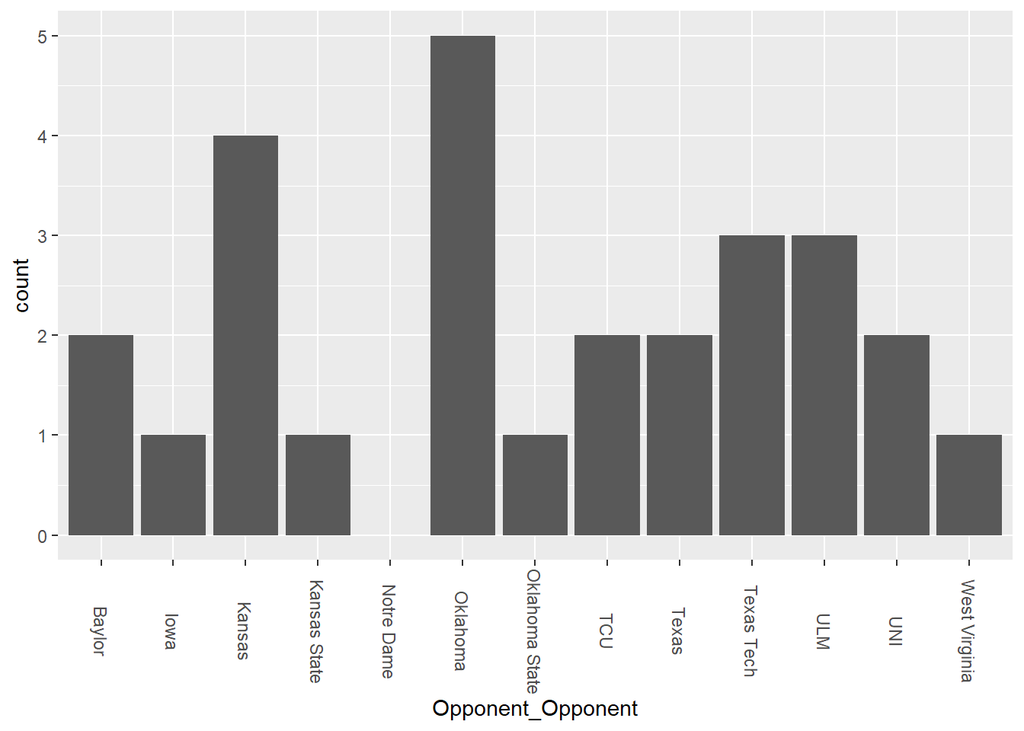

```r
offClean <- pivot_longer(offClean, cols = c(Rushing_ATT, Rushing_TD, Rushing_YDS, Receiving_TD, Receiving_YDS, Receiving_REC, Passing_YDS, Passing_TD, Passing_INT), names_to = "stat", values_to = "count" )
BrockPurdy <- offClean[offClean$Name == "Purdy, Brock",]

BPperformance <- BrockPurdy[BrockPurdy$stat == "Passing_TD",]
ISUperformance <- offClean[offClean$stat == "Receiving_TD" & !is.na(offClean$count),]
ISUperformance2 <- defClean[defClean$stat == "Tackles_Solo" & !is.na(defClean$count),]

ggplot(BPperformance, aes(x = Opponent_Opponent, weight = count)) + geom_bar() + theme(axis.text.x=element_text(angle = -90, vjust = 0.5))
```

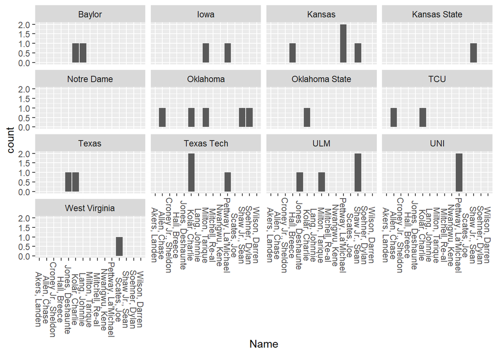

```r
ggplot(ISUperformance, aes(x = Name, weight = count)) + geom_bar() + theme(axis.text.x=element_text(angle = -90, vjust = 0.5)) + facet_wrap(~Opponent_Opponent)
```

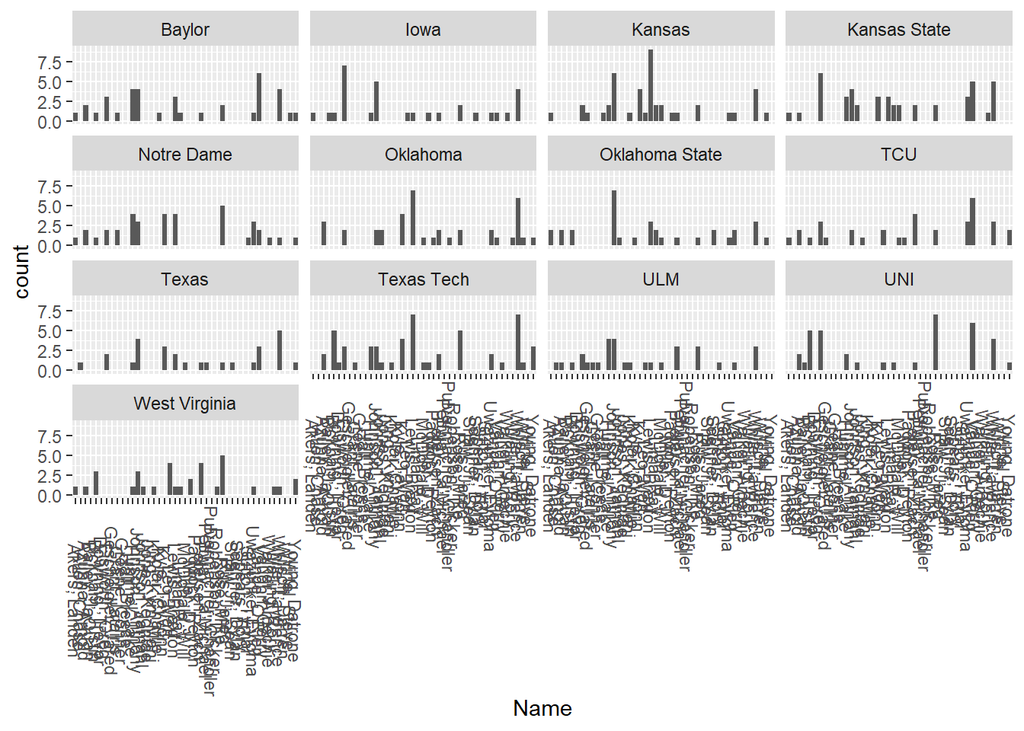

```r
ggplot(ISUperformance2, aes(x = Name, weight = count)) + geom_bar() + theme(axis.text.x=element_text(angle = -90, vjust = 0.5)) + facet_wrap(~Opponent_Opponent)
```

#### 3

```r
#Def
defClean2018 <- defense2018
defClean2018$Name <- factor(defClean2018$Name)
defClean2018$Opponent_Opponent <- factor(defClean2018$Opponent_Opponent)
defClean2018$Tackles_Solo <- as.numeric(defClean2018$Tackles_Solo)
defClean2018$Tackles_ASST <- as.numeric(defClean2018$Tackles_ASST)
defClean2018$Tackles_TFL <- as.numeric(defClean2018$Tackles_TFL)
defClean2018$Tackles_Sack <- as.numeric(defClean2018$Tackles_Sack)
defClean2018$Turnover_FF <- as.numeric(defClean2018$Turnover_FF)
defClean2018$Turnover_FR <- as.numeric(defClean2018$Turnover_FR)
defClean2018$Turnover_INT <- as.numeric(defClean2018$Turnover_INT)
defClean2018$Pass_QBH <- as.numeric(defClean2018$Pass_QBH)
defClean2018$Pass_PB <- as.numeric(defClean2018$Pass_PB)
defClean2018 <- pivot_longer(defClean2018, cols = c(Tackles_Solo, Tackles_ASST, Tackles_TFL, Tackles_Sack, Turnover_INT, Turnover_FR, Turnover_FF, Pass_PB, Pass_QBH), names_to = "stat", values_to = "count" )

defClean2019Stats <- select(defClean, Name, stat, count, Opponent_Opponent)
defClean2018Stats <- select(defClean2018, Name, stat, count, Opponent_Opponent)
defCleanStats <- left_join(defClean2018Stats, defClean2019Stats, by = c("Name", "stat", "Opponent_Opponent"), suffix = c("2018", "2019"))
defCleanStats <- defCleanStats[defCleanStats$stat == "Tackles_Solo",]

defCleanStats <- defCleanStats %>% group_by(Name) %>% summarise(c2018 = mean(count2018), c2019 = mean(count2019, na.rm = TRUE))
```

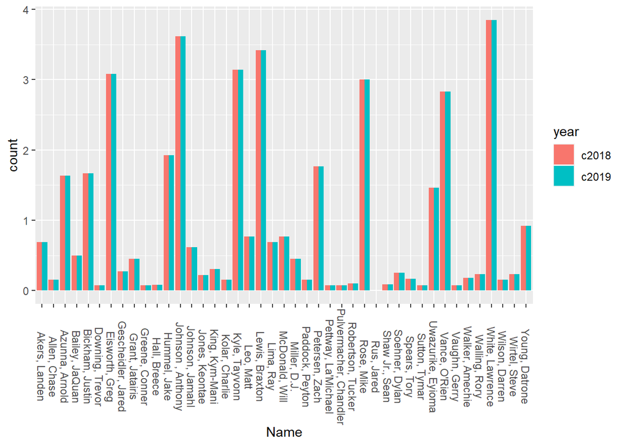

```r
defCleanStats <- pivot_longer(defCleanStats, cols = c(c2018, c2019), names_to = "year", values_to = "count")
ggplot(defCleanStats, aes(x = Name, weight = count, fill = year)) + geom_bar(position = 'dodge') + theme(axis.text.x=element_text(angle = -90, vjust = 0.5))
```

```r
#Off
offClean2018 <- offensive2018
offClean2018$Name <- factor(offClean2018$Name)
offClean2018$Opponent_Opponent <- factor(offClean2018$Opponent_Opponent)
offClean2018$Rushing_ATT <- as.numeric(offClean2018$Rushing_ATT)
offClean2018$Rushing_YDS <- as.numeric(offClean2018$Rushing_YDS)
offClean2018$Rushing_TD <- as.numeric(offClean2018$Rushing_TD)
offClean2018$Receiving_REC <- as.numeric(offClean2018$Receiving_REC)
offClean2018$Receiving_YDS <- as.numeric(offClean2018$Receiving_YDS)
offClean2018$Receiving_TD <- as.numeric(offClean2018$Receiving_TD)
offClean2018$Passing_YDS <- as.numeric(offClean2018$Passing_YDS)
offClean2018$Passing_TD <- as.numeric(offClean2018$Passing_TD)
offClean2018$Passing_INT <- as.numeric(offClean2018$Passing_INT)
offClean2018 <- pivot_longer(offClean2018, cols = c(Rushing_ATT, Rushing_TD, Rushing_YDS, Receiving_TD, Receiving_YDS, Receiving_REC, Passing_YDS, Passing_TD, Passing_INT), names_to = "stat", values_to = "count" )

offClean2019Stats <- select(offClean, Name, stat, count, Opponent_Opponent)
offClean2018Stats <- select(offClean2018, Name, stat, count, Opponent_Opponent)
offCleanStats <- left_join(offClean2018Stats, offClean2019Stats, by = c("Name", "stat", "Opponent_Opponent"), suffix = c("2018", "2019"))
offCleanStats <- offCleanStats[offCleanStats$stat == "Receiving_YDS",]
offCleanStats <- offCleanStats %>% group_by(Name) %>% summarise(c2018 = mean(count2018), c2019 = mean(count2019, na.rm = TRUE))
```

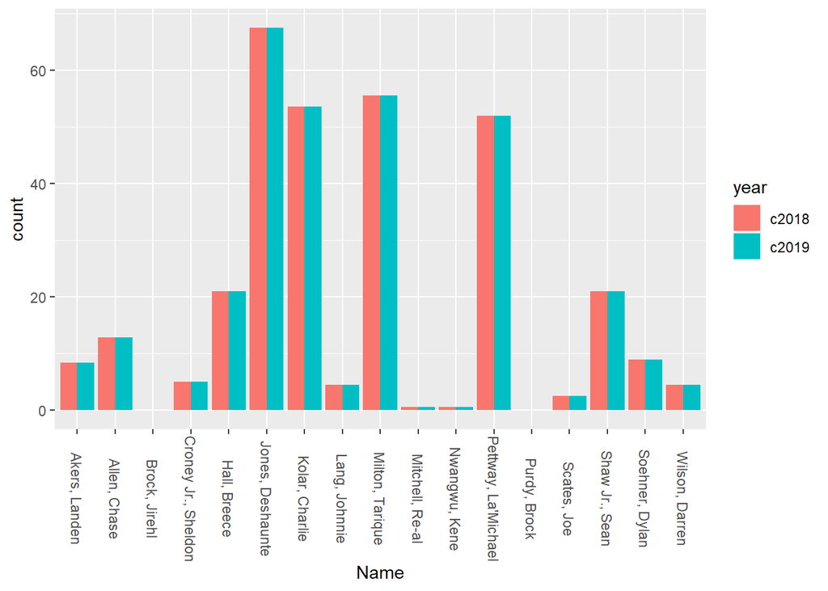

```r
offCleanStats[is.na(offCleanStats)] <- 0
offCleanStats <- pivot_longer(offCleanStats, cols = c(c2018, c2019), names_to = "year", values_to = "count")
ggplot(offCleanStats, aes(x = Name, weight = count, fill = year)) + geom_bar(position = 'dodge') + theme(axis.text.x=element_text(angle = -90, vjust = 0.5))
```